# PSTAT231 Final Project

Seyeon Jeon

2022-06-04

## Introduction

E-commerce is rapidly growing field of business and especially during pandemic, the growth of e-commerce market was remarkable. The sales accounted for 18% in 2020 and it is expected to reach 21.8% in 2024. I thought it would be useful if we can predict whether the customer will purchase the product or not with their browsing data.

The main objective of this project is to find a proper model to predict whether the customer is going to make purchase or not. The data set was obtained from [UCI’s machine learning repository](https://archive.ics.uci.edu/ml/datasets/Online+Shoppers+Purchasing+Intention+Dataset). The dataset contains 12330 sessions, which means 12330 people visited the website.

## Preparing Data and Packages

Setting seed to make the results repeatable.

```r
library(ggplot2)
library(tidymodels)
library(tidyverse)
library(janitor)
library(dplyr)

set.seed(45)
```

```r
data <- read.csv('online_shoppers_intention.csv')
head(data)
```

```
##   Administrative Administrative_Duration Informational Informational_Duration
## 1              0                       0             0                      0
## 2              0                       0             0                      0
## 3              0                       0             0                      0
## 4              0                       0             0                      0
## 5              0                       0             0                      0
## 6              0                       0             0                      0
##   ProductRelated ProductRelated_Duration BounceRates ExitRates PageValues
## 1              1                0.000000  0.20000000 0.2000000          0
## 2              2               64.000000  0.00000000 0.1000000          0
## 3              1                0.000000  0.20000000 0.2000000          0
## 4              2                2.666667  0.05000000 0.1400000          0
## 5             10              627.500000  0.02000000 0.0500000          0
## 6             19              154.216667  0.01578947 0.0245614          0
##   SpecialDay Month OperatingSystems Browser Region TrafficType
## 1          0   Feb                1       1      1           1
## 2          0   Feb                2       2      1           2
## 3          0   Feb                4       1      9           3
## 4          0   Feb                3       2      2           4
## 5          0   Feb                3       3      1           4
## 6          0   Feb                2       2      1           3
##         VisitorType Weekend Revenue
## 1 Returning_Visitor   FALSE   FALSE
## 2 Returning_Visitor   FALSE   FALSE
## 3 Returning_Visitor   FALSE   FALSE
## 4 Returning_Visitor   FALSE   FALSE
## 5 Returning_Visitor    TRUE   FALSE
## 6 Returning_Visitor   FALSE   FALSE
```

According to the description of the data set, “Administrative”, “Administrative Duration”, “Informational”, “Informational Duration”, “Product Related” and “Product Related Duration” represent the number of different types of pages visited by the visitor in that session and total time spent in each of these page categories.

```r
sapply(data, FUN = 'class')
```

```
##          Administrative Administrative_Duration           Informational
##               "integer"               "numeric"               "integer"
##  Informational_Duration          ProductRelated ProductRelated_Duration
##               "numeric"               "integer"               "numeric"
##             BounceRates               ExitRates              PageValues
##               "numeric"               "numeric"               "numeric"
##              SpecialDay                   Month        OperatingSystems
##               "numeric"             "character"               "integer"
##                 Browser                  Region             TrafficType
##               "integer"               "integer"               "integer"
##             VisitorType                 Weekend                 Revenue
##             "character"               "logical"               "logical"
```

So there is 18 columns in this data set which consists of 10 numerical and 8 categorical values. Our target value is ‘Revenue’ which indicates whether the customer purchased a product or not.

Checking if there’s any missing values.

```r
sum(is.na(data))
```

```
## [1] 0
```

Luckily, there is no missing values.

### Data Cleaning

To make it easier to deal with the data set, I manipulated the labels.

```r
data <- clean_names(data)
data$special_day <- factor(data$special_day)
data$revenue <- factor(data$revenue)
data$month <- factor(data$month)
data$region <- factor(data$region)
data$weekend <- factor(data$weekend)
```

I also checked the correlations between all the variables so that I can see the tendency. Before plotting correlation matrix, I one-hot coded all the nominal values so that all of the predictors can be included in the plot.

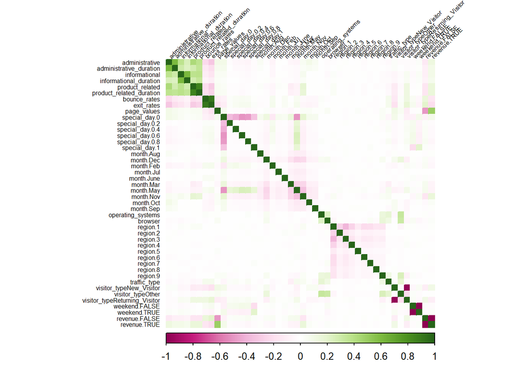

```r
library(corrplot)
library(caret)
dmy <- dummyVars(" ~ .", data = data)
d_data <- data.frame(predict(dmy, newdata = data))

corrplot(cor(d_data), method = 'color', tl.col = 'black', tl.srt = 45, tl.cex = 0.5,
         col = COL2('PiYG'), cl.pos = 'b')
```

The plot shows that ‘administrative’ and ‘administrative duration’, ‘informational’ and ‘informational duration’, ‘product related’ and ‘product related duration’s are highly correlated and this can cause collinearity problem when fitting models. So, I replaced these labels with the average time spent on each type of page for example, ’administrative duration’ divided by ‘administrative’ and named it ‘average_administration’.

```r
average_administrative <- data$administrative_duration / data$administrative
average_informational <- data$informational_duration / data$informational
average_prod_related <- data$product_related_duration / data$product_related
nec_data <- subset(data, select = -c(administrative, administrative_duration, informational, informational_duration, product_related, product_related_duration))
clean_data <- cbind(nec_data, average_administrative, average_informational, average_prod_related)
```

```r
clean_data
```

[output not shown]

[output cut: 19987 more lines]

There are some NaN values because ‘administrative’, ‘informational’, and ‘product related’ columns had 0 values. Since it means that the customer didn’t visit that type of page at all, I replaced all NaN values with 0.

```r
clean_data[is.na(clean_data)] <- 0
sum(is.na(clean_data))
```

```
## [1] 0
```

```r
clean_data
```

[output not shown]

[output cut: 19987 more lines]

### Data Spliting

Now, I am going to split the data. Since the goal of this project is to predict ‘revenue’ value, stratified random sampling using ‘revenue’ as strata would be suitable.

```r
data_split <- clean_data %>%
  initial_split(prop = 0.8, strata = revenue)

data_train <- training(data_split)
data_test <- testing(data_split)

nrow(data_train)
```

```
## [1] 9863
```

I used 0.8 probability to make sure I have enough number of training data. After the split, training data has 9863 observations. From this chunk, I am going to use the train set for EDA.

## Exploratory Data Analysis

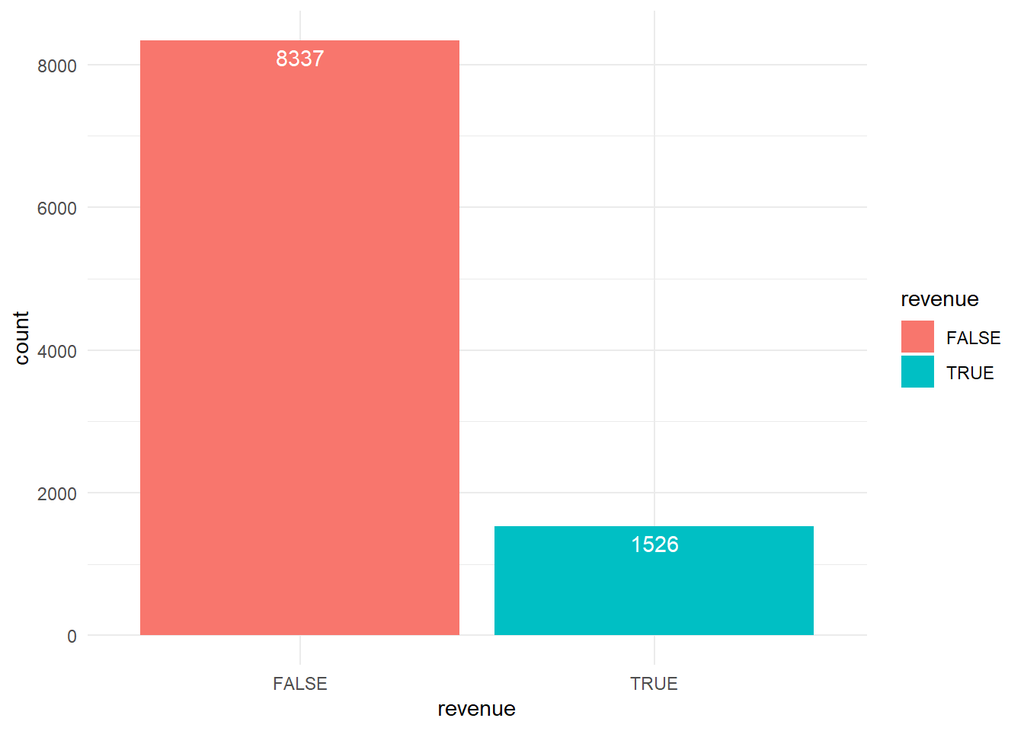

```r
ggplot(data_train, aes(revenue, fill = revenue)) + geom_bar() + geom_text(aes(label = ..count..), stat = 'count', vjust = 1.5, color = 'white') + theme_minimal()
```

There is much more ‘FALSE’ data compared to ‘TRUE’ data which means much more people didn’t actually make a purchase. Since we are trying to predict revenue, we should definitely be using strata to make a balanced split.

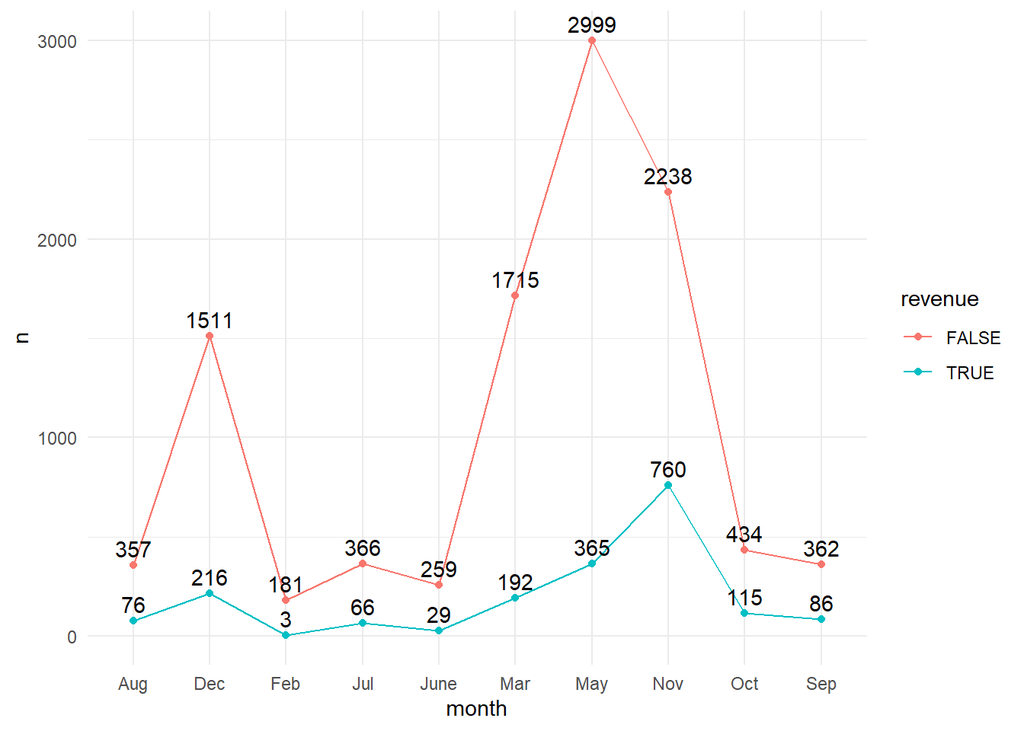

```r
ggplot(count(data, month, revenue), aes(x = month, y = n, group = revenue)) + geom_line(aes(color = revenue)) + geom_point(aes(color = revenue)) + geom_text(aes(label = n), vjust = - 0.5) + theme_minimal()
```

```r
month_rate <- count(subset(clean_data, revenue == TRUE), month)['n'] / count(clean_data, month)['n']
month_rate <- cbind(month_rate, count(clean_data, month)[1])
month_rate
```

```
##             n month
## 1  0.17551963   Aug
## 2  0.12507238   Dec
## 3  0.01630435   Feb
## 4  0.15277778   Jul
## 5  0.10069444  June
## 6  0.10068170   Mar
## 7  0.10850178   May
## 8  0.25350233   Nov
## 9  0.20947177   Oct
## 10 0.19196429   Sep
```

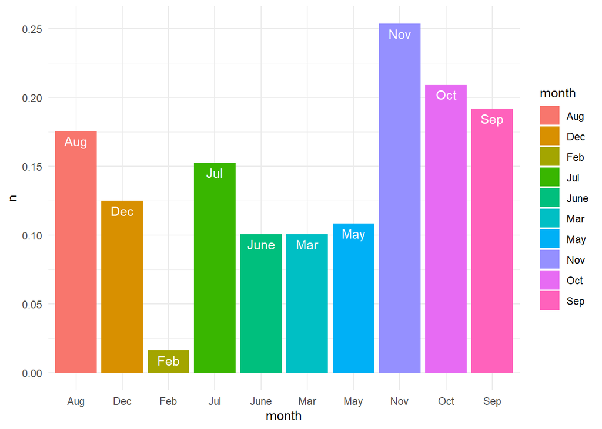

```r
ggplot(month_rate, aes(x = month, y = n, fill = month)) + geom_bar(stat = 'identity') + geom_text(aes(label = month), vjust = 1.5, color = 'white') + theme_minimal()
```

We can see that the number of people visiting the e-commerce website was significantly high in May and November. However, number of the visitors was the highest in May but the rate of purchase was not they highest. The purchase rate was the highest in November and the lowest in February.

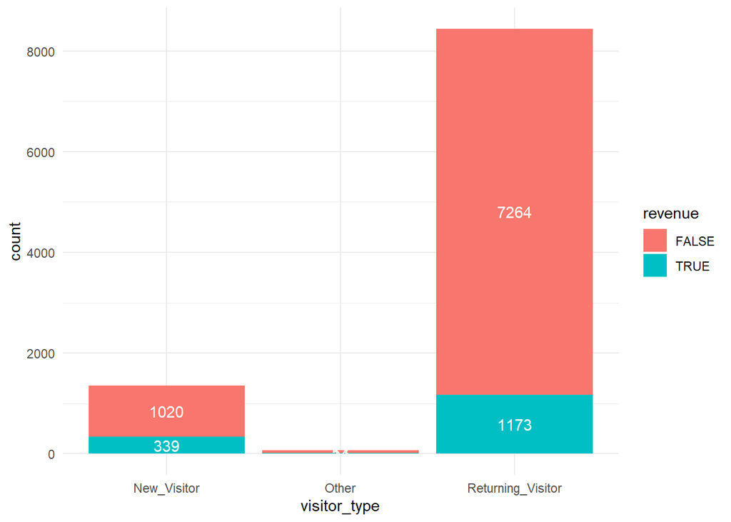

```r
ggplot(data_train, aes(visitor_type, fill = revenue)) + geom_bar() + geom_text(aes(label = ..count..), stat = 'count', position = position_stack(vjust= 0.5), color = 'white') + theme_minimal()
```

```r
visitor_rate <- count(subset(clean_data, revenue == TRUE), visitor_type)['n'] / count(clean_data, visitor_type)['n']
visitor_rate <- cbind(visitor_rate, count(clean_data, visitor_type)[1])
visitor_rate
```

```
##           n      visitor_type
## 1 0.2491145       New_Visitor
## 2 0.1882353             Other
## 3 0.1393233 Returning_Visitor
```

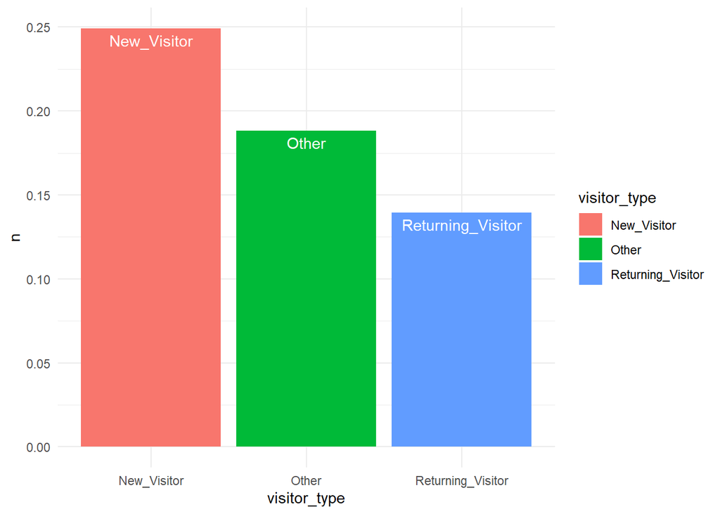

```r
ggplot(visitor_rate, aes(x = visitor_type, y = n, fill = visitor_type)) + geom_bar(stat = 'identity') + geom_text(aes(label = visitor_type), vjust = 1.5, color = 'white') + theme_minimal()
```

In case of visitor types, the customer who visited the website for the first time had the highest purchase rate.

## Model Building and Fitting

### K-cross Validation

```r
train_folds <- vfold_cv(data_train, v = 5, strata = revenue)
```

### Creating a Recipe

```r
shop_recipe <- recipe(revenue ~ ., data = data_train) %>%
  step_dummy(all_nominal_predictors(), one_hot = TRUE) %>%
  step_center(all_predictors()) %>%
  step_scale(all_predictors())
```

One hot encoded all the nominal predictors.

### Models

> Random Forest

```r
library(randomForest)
rf_model <- rand_forest(
  min_n = tune(),
  mtry = tune()) %>%
  set_engine('randomForest', importance = TRUE) %>%
  set_mode('classification')

rf_wf <- workflow() %>%
  add_model(rf_model) %>%
  add_recipe(shop_recipe)
```

Fitting the model defined above.

```r
rf_grid <- grid_regular(mtry(range = c(1, 10)),
                        min_n(range = c(1, 10)),
                              levels = 2)

rf_tune <- rf_wf %>%
   tune_grid(resamples = train_folds,
            grid = rf_grid)

save(rf_tune, rf_wf, file = "model_fitting/randomforest.rda")
```

I tried running this chunk with 10 levels but it took over an hour and my laptop was dying so I changed to 2. Also saved as a seperate file. The example final project helped me a lot through this procedure.

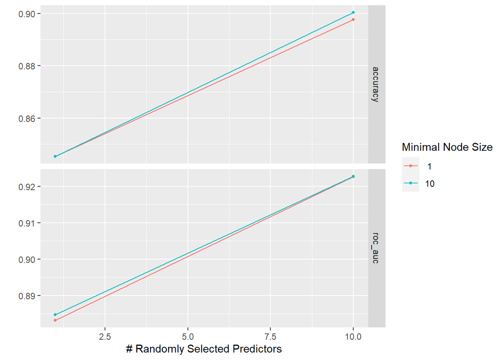

```r
autoplot(rf_tune)
```

Finding the parameter to make the most accurate model, and fitting test data set to the best model.

```r
collect_metrics(rf_tune) %>% arrange(desc(mean))
```

```
## # A tibble: 8 x 8
##    mtry min_n .metric  .estimator  mean     n   std_err .config
##   <int> <int> <chr>    <chr>      <dbl> <int>     <dbl> <chr>
## 1    10    10 roc_auc  binary     0.923     5 0.00303   Preprocessor1_Model4
## 2    10     1 roc_auc  binary     0.923     5 0.00244   Preprocessor1_Model2
## 3    10    10 accuracy binary     0.900     5 0.00204   Preprocessor1_Model4
## 4    10     1 accuracy binary     0.898     5 0.00118   Preprocessor1_Model2
## 5     1    10 roc_auc  binary     0.885     5 0.00458   Preprocessor1_Model3
## 6     1     1 roc_auc  binary     0.883     5 0.00686   Preprocessor1_Model1
## 7     1     1 accuracy binary     0.845     5 0.0000754 Preprocessor1_Model1
## 8     1    10 accuracy binary     0.845     5 0.0000754 Preprocessor1_Model3
```

```r
best_parameter <- select_best(rf_tune, metric = 'accuracy')
rf_final <- finalize_workflow(rf_wf, best_parameter)
rf_final_fit <- fit(rf_final, data = data_train)
```

```r
rf_final_fit
```

```
## == Workflow [trained] ==========================================================
## Preprocessor: Recipe
## Model: rand_forest()
##
## -- Preprocessor ----------------------------------------------------------------
## 3 Recipe Steps
##
## * step_dummy()
## * step_center()
## * step_scale()
##
## -- Model -----------------------------------------------------------------------
##
## Call:
##  randomForest(x = maybe_data_frame(x), y = y, mtry = min_cols(~10L,      x), nodesize = min_rows(~10L, x), importance = ~TRUE)
##                Type of random forest: classification
##                      Number of trees: 500
## No. of variables tried at each split: 10
##
##         OOB estimate of  error rate: 10%
## Confusion matrix:
##       FALSE TRUE class.error
## FALSE  8035  302  0.03622406
## TRUE    684  842  0.44823067
```

- Evaluate

```r
augment(rf_final_fit, new_data = data_test) %>%
  accuracy(truth = revenue, estimate = .pred_class)
```

```
## # A tibble: 1 x 3
##   .metric  .estimator .estimate
##   <chr>    <chr>          <dbl>
## 1 accuracy binary         0.906
```

> Boosted Tree

For boosted tree model, I tuned the number of trees.

```r
library(xgboost)
bt_model <- boost_tree(trees = tune()) %>%
  set_engine('xgboost') %>%
  set_mode('classification')

bt_wf <- workflow() %>%
  add_model(bt_model) %>%
  add_recipe(shop_recipe)
```

Fitting the model defined above.

```r
bt_grid <- grid_regular(trees(range = c(10, 2000)), levels = 5)
bt_tune<- tune_grid(
  bt_wf,
  resamples = train_folds,
  grid = bt_grid)

save(bt_tune, bt_wf, file = "model_fitting/boostedftree.rda")
```

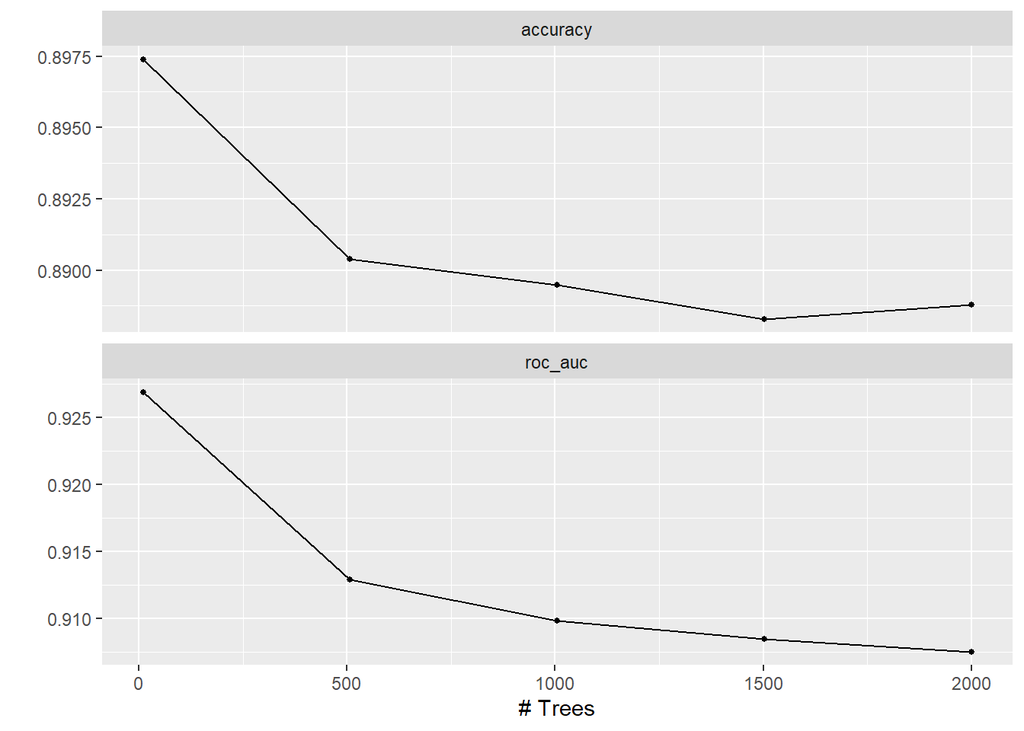

```r
autoplot(bt_tune)
```

```r
collect_metrics(bt_tune) %>% arrange(desc(mean))
```

```
## # A tibble: 10 x 7
##    trees .metric  .estimator  mean     n std_err .config
##    <int> <chr>    <chr>      <dbl> <int>   <dbl> <chr>
##  1    10 roc_auc  binary     0.927     5 0.00103 Preprocessor1_Model1
##  2   507 roc_auc  binary     0.913     5 0.00277 Preprocessor1_Model2
##  3  1005 roc_auc  binary     0.910     5 0.00290 Preprocessor1_Model3
##  4  1502 roc_auc  binary     0.908     5 0.00297 Preprocessor1_Model4
##  5  2000 roc_auc  binary     0.907     5 0.00308 Preprocessor1_Model5
##  6    10 accuracy binary     0.897     5 0.00267 Preprocessor1_Model1
##  7   507 accuracy binary     0.890     5 0.00294 Preprocessor1_Model2
##  8  1005 accuracy binary     0.889     5 0.00266 Preprocessor1_Model3
##  9  2000 accuracy binary     0.889     5 0.00188 Preprocessor1_Model5
## 10  1502 accuracy binary     0.888     5 0.00239 Preprocessor1_Model4
```

```r
best_parameter <- select_best(bt_tune, metric = 'accuracy')
bt_final <- finalize_workflow(bt_wf, best_parameter)
bt_final_fit <- fit(bt_final, data = data_train)
```

- Evaluate

```r
augment(bt_final_fit, new_data = data_test) %>%
  accuracy(truth = revenue, estimate = .pred_class)
```

```
## # A tibble: 1 x 3
##   .metric  .estimator .estimate
##   <chr>    <chr>          <dbl>
## 1 accuracy binary         0.907
```

> KNN

Here, I am using K-Nearest Neighbor model.

```r
knn_model <-
  nearest_neighbor(
    neighbors = tune(),
    mode = 'classification') %>%
  set_engine('kknn')

knn_wf <- workflow() %>%
  add_model(knn_model) %>%
  add_recipe(shop_recipe)
```

Fitting the model defined above.

```r
library(kknn)
knn_grid <- grid_regular(parameters(knn_model), levels = 2)
knn_tune <- tune_grid(
  knn_wf,
  resamples = train_folds,
  grid = knn_grid)

save(knn_tune, knn_wf, file = "model_fitting/knn.rda")
```

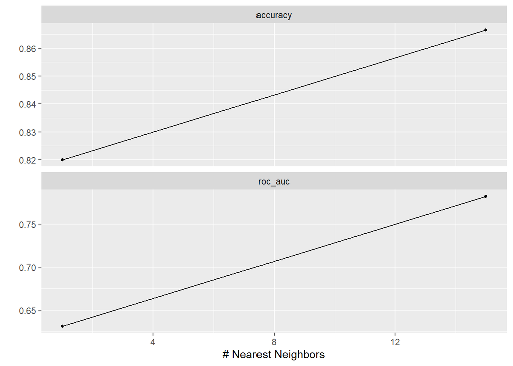

```r
autoplot(knn_tune)
```

```r
collect_metrics(knn_tune) %>% arrange(desc(mean))
```

```
## # A tibble: 4 x 7
##   neighbors .metric  .estimator  mean     n std_err .config
##       <int> <chr>    <chr>      <dbl> <int>   <dbl> <chr>
## 1        15 accuracy binary     0.867     5 0.00136 Preprocessor1_Model2
## 2         1 accuracy binary     0.820     5 0.00308 Preprocessor1_Model1
## 3        15 roc_auc  binary     0.783     5 0.00352 Preprocessor1_Model2
## 4         1 roc_auc  binary     0.631     5 0.00629 Preprocessor1_Model1
```

```r
best_parameter <- select_best(knn_tune, metric = 'accuracy')
knn_final <- finalize_workflow(knn_wf, best_parameter)
knn_final_fit <- fit(knn_final, data = data_train)
```

- Evaluate

```r
augment(knn_final_fit, new_data = data_test) %>%
  accuracy(truth = revenue, estimate = .pred_class)
```

```
## # A tibble: 1 x 3
##   .metric  .estimator .estimate
##   <chr>    <chr>          <dbl>
## 1 accuracy binary         0.870
```

As the fourth model, I had a neural network model. But it kept returning error that I was not able to fix. The model is still available in the rmd file.

## References

Data Source: https://archive.ics.uci.edu/ml/datasets/Online+Shoppers+Purchasing+Intention+Dataset

Example final project https://gauchospace.ucsb.edu/courses/pluginfile.php/4550966/mod_resource/content/2/Final-Project.html#

https://statisticsbyjim.com/regression/multicollinearity-in-regression-analysis/

https://www.r-bloggers.com/2021/04/deep-neural-network-in-r/

https://towardsdatascience.com/can-you-predict-if-a-customer-will-make-a-purchase-on-a-website-e6843ec264ae